# 1 - Header

# What NBA Position Do You Play?

Fall 2024 Data Science Project

Ritvik Venkat, Rahul Anantuni, Ben Weatherhead, Soumil Girdhar, Anshul Ganumpally

**Contributions**

Soumil Girdhar: Soumil helped with cleaning up the missing/unknown data from the dataset and came up with a handful of questions that we wanted to answer using the dataset. He also conducted the first statistical analysis (bench press vs body fat percentage), and helped with the developing, training, and testing of the ML model by tuning hyperparameters such as test size, deciding which features of the data set to use, and choosing the best model to use.

Ritvik Venkat: Ritvik worked on date cleaning and deciding which data points were unnecessary to the overarching goal of the project. He also worked on the height of a center or not z test to better understand the relationship between height and position. Finally, he helped with machine learning by helping build the logic for the machine learning model and created graphs that analyzed each individual relationship between a feature and position.

Rahul Anantuni: Rahul initially loaded the dataset and worked on cleaning it. He conducted the third statistical method, Position vs. Weight, using a chi-square test for checkpoint 2 as part of the data exploration process. He also completed the data visualization for part 3 using a heatmap and compiled all code and insights into a final submission website hosted on GitHub.

Ben Weatherhead: Ben found the dataset and helped in creating the idea of using physical attributes to predict a player’s position. He assisted in cleaning and creating the three ideas on which we made conclusions in the Data Exploration and Summary Statistics section, assisting in the coding in all three while doing the most programming in the “Position vs. Weight” test. He helped develop the ML algorithm and helped train and test the model to determine which physical attributes improved and hurt the accuracy. Lastly, he helped write the insights at the end, notably explaining why the model had its accuracy.

Anshul Ganumpally: Anshul helped with cleaning and assisted Ben with testing the position vs weight relationship. He did research on the insights that could be gained from the results of machine learning and used the data to write clear conclusions to the project.

# 2 - Introduction

We are all passionate about the NBA and this data set has a variety of different information across comprehensive spreadsheets that are easy to understand but provide a challenge when analyzing.

Our topic is to predict what position an NBA player should play based on their physical attributes. We sought to discover how much of a correlation there was between physical stats such as height and bench press and position that existing NBA players play. Answering these questions is important because it provides valuable insights to three critical aspects of the NBA. For a player entering the league, this helps them decide where they fit in on a team and where they are likely to succeed. For a coach, it helps them know who to start at what position. Additionally, for a General Manager of a team, this helps them know where a player will succeed and when they are drafting, they can draft a player who fills the position they are in need of. Lastly the average basketball player could use this too even if they are not in the NBA. But since even average NBA point guards are much larger than the average person, this will not help you much unless you are at least that size as well.

```python
import kagglehub
import pandas as pd
import os
import matplotlib.pyplot as plt
import seaborn as sns

from sklearn.model_selection import train_test_split
from sklearn.preprocessing import StandardScaler, LabelEncoder
from sklearn.ensemble import RandomForestClassifier
from sklearn.neighbors import KNeighborsClassifier
from sklearn.tree import DecisionTreeClassifier
from sklearn.linear_model import LogisticRegression
from sklearn.metrics import classification_report, accuracy_score
from scipy import stats
from scipy.stats import chi2_contingency
```

# 3 - Data Curation

Kaggle Link: https://www.kaggle.com/datasets/wyattowalsh/basketball  
Description: The dataset contains NBA player combine statistics from 2000 onwards, including various physical attributes such as height, weight, wingspan, bench press performance, and position. This data offers insights into the physical profiles of players, providing a comprehensive view of their measurable athletic abilities. This kaggle page also included other datasets such as box scores and game results, but for the scope of this project we decided to focus on the NBA Draft Combine Statistics.

```python
path = kagglehub.dataset_download("wyattowalsh/basketball")

data_files = os.path.join(path, 'csv')

data_file = os.path.join(data_files, 'draft_combine_stats.csv')
df = pd.read_csv(data_file)

print("Initial DataFrame Info:")
print(df.info())
print("\nMissing Values:")
print(df.isnull().sum())
print(df.head())
```

```
Initial DataFrame Info:
<class 'pandas.core.frame.DataFrame'>
RangeIndex: 1202 entries, 0 to 1201
Data columns (total 47 columns):
 #   Column                        Non-Null Count  Dtype
---  ------                        --------------  -----
 0   season                        1202 non-null   int64
 1   player_id                     1202 non-null   int64
 2   first_name                    1202 non-null   object
 3   last_name                     1202 non-null   object
 4   player_name                   1202 non-null   object
 5   position                      1197 non-null   object
 6   height_wo_shoes               1153 non-null   float64
 7   height_wo_shoes_ft_in         1153 non-null   object
 8   height_w_shoes                1008 non-null   float64
 9   height_w_shoes_ft_in          1008 non-null   object
 10  weight                        1152 non-null   float64
 11  wingspan                      1153 non-null   float64
 12  wingspan_ft_in                1153 non-null   object
 13  standing_reach                1152 non-null   float64
 14  standing_reach_ft_in          1152 non-null   object
 15  body_fat_pct                  1003 non-null   float64
 16  hand_length                   719 non-null    float64
 17  hand_width                    719 non-null    float64
 18  standing_vertical_leap        1017 non-null   float64
 19  max_vertical_leap             1017 non-null   float64
 20  lane_agility_time             1008 non-null   float64
 21  modified_lane_agility_time    411 non-null    float64
 22  three_quarter_sprint          1012 non-null   float64
 23  bench_press                   808 non-null    float64
 24  spot_fifteen_corner_left      74 non-null     object
 25  spot_fifteen_break_left       76 non-null     object
 26  spot_fifteen_top_key          76 non-null     object
 27  spot_fifteen_break_right      76 non-null     object
 28  spot_fifteen_corner_right     76 non-null     object
 29  spot_college_corner_left      245 non-null    object
 30  spot_college_break_left       166 non-null    object
 31  spot_college_top_key          166 non-null    object
 32  spot_college_break_right      166 non-null    object
 33  spot_college_corner_right     166 non-null    object
```

[output cut: 101 more lines]

```
   off_drib_college_top_key  off_drib_college_break_right  on_move_fifteen  \
0                       NaN                           NaN              NaN
1                       NaN                           NaN              NaN
2                       NaN                           NaN              NaN
3                       NaN                           NaN              NaN
4                       NaN                           NaN              NaN

   on_move_college
0              NaN
1              NaN
2              NaN
3              NaN
4              NaN

[5 rows x 47 columns]
```

```python
# Handling Missing Values
num_cols = df.select_dtypes(include=['float64']).columns
cat_cols = df.select_dtypes(include=['object']).columns

df[num_cols] = df[num_cols].fillna(df[num_cols].mean())
df[cat_cols] = df[cat_cols].fillna('Unknown')
```

```python
df.rename(columns={
    'player_name': 'full_name',
    'height_wo_shoes': 'height_without_shoes',
    'height_w_shoes': 'height_with_shoes'
}, inplace=True)
```

```python
columns_to_drop = [
    'spot_fifteen_corner_left', 'spot_fifteen_break_left', 'spot_fifteen_top_key',
    'spot_fifteen_break_right', 'spot_fifteen_corner_right', 'spot_college_corner_left',
    'spot_college_break_left', 'spot_college_top_key', 'spot_college_break_right',
    'spot_college_corner_right', 'spot_nba_corner_left', 'spot_nba_break_left',
    'spot_nba_top_key', 'spot_nba_break_right', 'spot_nba_corner_right',
    'off_drib_fifteen_break_left', 'off_drib_fifteen_top_key', 'off_drib_fifteen_break_right',
    'off_drib_college_break_left', 'off_drib_college_top_key', 'off_drib_college_break_right',
    'on_move_fifteen', 'on_move_college', 'height_w_shoes_ft_in'
]


df = df.drop(columns=columns_to_drop, errors = 'ignore')

print("\nCleaned DataFrame Info:")
print(df.info())
print("\nFirst few rows of the cleaned DataFrame:")
print(df.head())
```

```
Cleaned DataFrame Info:
<class 'pandas.core.frame.DataFrame'>
RangeIndex: 1202 entries, 0 to 1201
Data columns (total 23 columns):
 #   Column                      Non-Null Count  Dtype
---  ------                      --------------  -----
 0   season                      1202 non-null   int64
 1   player_id                   1202 non-null   int64
 2   first_name                  1202 non-null   object
 3   last_name                   1202 non-null   object
 4   full_name                   1202 non-null   object
 5   position                    1202 non-null   object
 6   height_without_shoes        1202 non-null   float64
 7   height_wo_shoes_ft_in       1202 non-null   object
 8   height_with_shoes           1202 non-null   float64
```

[output cut: 55 more lines]

# 4 - Exploratory data analysis

**Test 1**

Position vs Strength (Bench Press)

```python
strength_df = df[['position', 'bench_press', 'body_fat_pct']]
strength_df = strength_df.dropna()
strength_df.drop('Unknown', inplace=True, errors='ignore')
strength_df['position'] = strength_df['position'].apply(lambda x: 'PG' if x in ['PG', 'PG-SG'] else x)
strength_df['position'] = strength_df['position'].apply(lambda x: 'SG' if x in ['SG', 'SG-PG', 'SG-SF'] else x)
strength_df['position'] = strength_df['position'].apply(lambda x: 'SF' if x in ['SF', 'SF-SG', 'SF-PF'] else x)
strength_df['position'] = strength_df['position'].apply(lambda x: 'PF' if x in ['PF', 'PF-SF','PF-C'] else x)
strength_df['position'] = strength_df['position'].apply(lambda x: 'C' if x in ['C', 'C-PF'] else x)
```

```python
strength_stats = strength_df.groupby('position')[['bench_press', 'body_fat_pct']].agg(['mean', 'std', 'min', 'max'])
strength_stats.drop('Unknown', inplace=True, errors='ignore')
strength_stats
```

| position | bench_press mean | bench_press std | bench_press min | bench_press max | body_fat_pct mean | body_fat_pct std | body_fat_pct min | body_fat_pct max |
| --- | --- | --- | --- | --- | --- | --- | --- | --- |
| C | 10.858647 | 4.123614 | 0.0 | 22.0 | 8.769832 | 3.370098 | 2.7 | 21.0 |
| PF | 11.357239 | 4.683443 | 0.0 | 26.0 | 8.175452 | 2.610228 | 3.2 | 20.8 |
| PG | 9.175219 | 4.069095 | 0.0 | 21.0 | 6.532423 | 2.081945 | 2.6 | 15.8 |
| SF | 9.998647 | 4.467054 | 0.0 | 26.0 | 7.053252 | 2.136138 | 2.9 | 18.5 |
| SG | 9.472632 | 4.239265 | 0.0 | 25.0 | 6.664851 | 1.854192 | 3.2 | 13.5 |

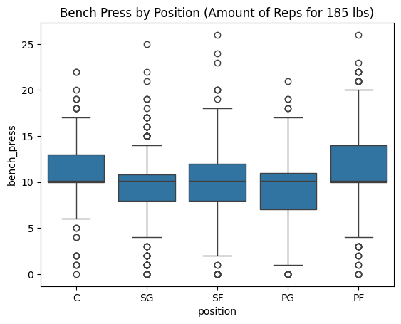

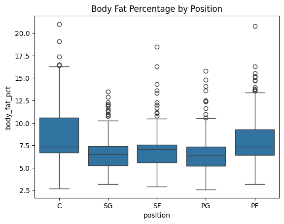

```python
# Boxplot for bench_press across positions
strength_df = strength_df[strength_df['position'] != 'Unknown']


sns.boxplot(x='position', y='bench_press', data=strength_df)
plt.title('Bench Press by Position (Amount of Reps for 185 lbs)')
plt.show()

# Boxplot for body_fat_pct across positions
sns.boxplot(x='position', y='body_fat_pct', data=strength_df)
plt.title('Body Fat Percentage by Position')
plt.show()
```

```python
# Separate data by the 5 positions
point_guards = strength_df[(strength_df['position'] == 'PG') ]
shooting_guards = strength_df[(strength_df['position'] == 'SG') ]
small_forwards = strength_df[(strength_df['position'] == 'SF')]
power_forwards = strength_df[(strength_df['position'] == 'PF')]
centers = strength_df[(strength_df['position'] == 'C')]

updated_strength_df = pd.concat([point_guards, shooting_guards, small_forwards, power_forwards, centers])
# ANOVA for bench_press
f_stat, p_value = stats.f_oneway(point_guards['bench_press'], shooting_guards['bench_press'], small_forwards['bench_press'],
                                 power_forwards['bench_press'], centers['bench_press'])
print(f"ANOVA Bench Press: F-statistic={f_stat}, p-value={p_value}")

# ANOVA for body_fat_pct
f_stat, p_value = stats.f_oneway(point_guards['body_fat_pct'], shooting_guards['body_fat_pct'], small_forwards['body_fat_pct'],
                                 power_forwards['body_fat_pct'], centers['body_fat_pct'])
print(f"ANOVA Body Fat %: F-statistic={f_stat}, p-value={p_value}")
```

```
ANOVA Bench Press: F-statistic=11.550800319370834, p-value=3.3334236274617224e-09
ANOVA Body Fat %: F-statistic=36.16877365618975, p-value=1.4639722800408588e-28
```

```python
from statsmodels.stats.multicomp import pairwise_tukeyhsd

# Tukey HSD for bench_press
tukey_bench_press = pairwise_tukeyhsd(strength_df['bench_press'], strength_df['position'])
print(tukey_bench_press)

# Tukey HSD for body_fat_pct
tukey_body_fat = pairwise_tukeyhsd(strength_df['body_fat_pct'], strength_df['position'])
print(tukey_body_fat)
```

```
Multiple Comparison of Means - Tukey HSD, FWER=0.05
====================================================
group1 group2 meandiff p-adj   lower   upper  reject
----------------------------------------------------
     C     PF   0.4986 0.7823 -0.6907  1.6879  False
     C     PG  -1.6834 0.0019 -2.9196 -0.4473   True
     C     SF    -0.86 0.3313 -2.1129  0.3929  False
     C     SG   -1.386 0.0143 -2.5872 -0.1848   True
    PF     PG   -2.182    0.0  -3.211 -1.1531   True
    PF     SF  -1.3586 0.0038 -2.4076 -0.3096   True
    PF     SG  -1.8846    0.0 -2.8713 -0.8979   True
    PG     SF   0.8234 0.2468 -0.2785  1.9253  False
    PG     SG   0.2974 0.9366 -0.7453  1.3401  False
    SF     SG   -0.526 0.6582 -1.5885  0.5365  False
----------------------------------------------------
Multiple Comparison of Means - Tukey HSD, FWER=0.05
====================================================
group1 group2 meandiff p-adj   lower   upper  reject
----------------------------------------------------
     C     PF  -0.5944 0.0921 -1.2449  0.0561  False
     C     PG  -2.2374    0.0 -2.9136 -1.5612   True
     C     SF  -1.7166    0.0 -2.4019 -1.0312   True
     C     SG   -2.105    0.0  -2.762 -1.4479   True
    PF     PG   -1.643    0.0 -2.2059 -1.0802   True
    PF     SF  -1.1222    0.0  -1.696 -0.5484   True
    PF     SG  -1.5106    0.0 -2.0503 -0.9709   True
    PG     SF   0.5208  0.127 -0.0819  1.1236  False
    PG     SG   0.1324 0.9695 -0.4379  0.7028  False
    SF     SG  -0.3884 0.3591 -0.9696  0.1928  False
----------------------------------------------------
```

```python
# Correlation within each position
correlation = strength_df.groupby('position')[['bench_press', 'body_fat_pct']].corr().unstack().iloc[:,1]
print(correlation)
```

```
position
C     0.093441
PF    0.069794
PG   -0.166722
SF    0.041379
SG   -0.003886
Name: (bench_press, body_fat_pct), dtype: float64
```

**Test 2**

Height vs Center or not

Conducting a Z-Test based whether the height impacts whether a player can be a center

```python
import numpy as np
# First we extracted the data based on whether or not they are a center along with their height
center = df[df['position'].str.startswith('C')]
not_center = df[~df['position'].str.startswith('C')]

center_height = center['height_without_shoes']
not_center_height = not_center['height_without_shoes']
```

```python
# Now we calculated the means and standard deviations
center_mean_height = center_height.mean()
center_std_height = center_height.std()
center_count = len(center_height)


not_center_mean_height = not_center_height.mean()
not_center_std_height = not_center_height.std()
not_center_count = len(not_center_height)

print(center_mean_height)
print(center_std_height)
print(center_count)

print(not_center_mean_height)
print(not_center_std_height)
print(not_center_count)
```

```
81.83044810638913
1.94534911968867
150
76.96355226405575
2.948378915068926
1052
```

```python
# Now find the z statistic and p value
z = (center_mean_height - not_center_mean_height) / np.sqrt((center_std_height ** 2 / center_count) + (not_center_std_height**2 / not_center_count))

p = 2 * (1 - stats.norm.cdf(abs(z)))
p
```

```
0.0
```

Since the p-value is less 0.05 we can confidently reject the null hypothesis, indicating that centers are taller than non-centers and there is a difference between the height of centers and non-centers

```python
# Dataframe for plotting

center.loc[:, 'rounded'] = center['height_without_shoes'].round().astype(int)
not_center.loc[:, 'rounded'] = not_center['height_without_shoes'].round().astype(int)

counts_1 = center.groupby('rounded').size()
counts_2 = not_center.groupby('rounded').size()

heights = range(min(df['height_without_shoes'].round().astype(int)), max(df['height_without_shoes'].round().astype(int)) + 1)
counts = pd.DataFrame({'Center' : counts_1, 'Not Center' : counts_2}).reindex(heights, fill_value = 0)
```

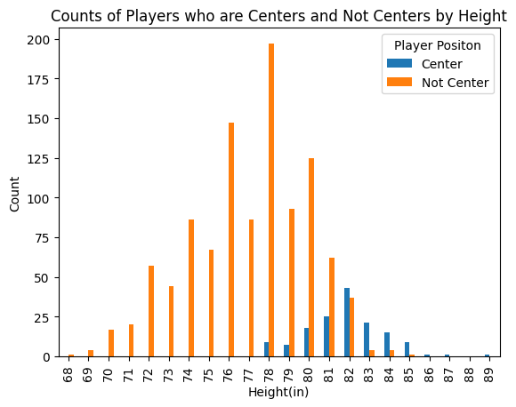

```python
counts.plot(kind = 'bar')
plt.title('Counts of Players who are Centers and Not Centers by Height')
plt.xlabel('Height(in)')
plt.ylabel('Count')
plt.legend(title = 'Player Positon')
```

**Conclusion**

This test compared heights and whether or not a player is a center. This was a good way of seeing if height was truly as important to the playing center as usually perceived. By using a z test we could tell if whether or not a player was a center and height had a relationship and we could see if we could be truly confident in our conclusion. The test resulted in a p value of almost 0 (< 0.05) and as a result we rejected the null hypothesis, indicating that there was a strong relationship between centers and height.

**Test 3**

Position vs Weight

```python
weight_df = df[['weight', 'position']].copy()

weight_df = weight_df[weight_df['position'] != 'Unknown']
weight_df['position'] = weight_df['position'].apply(lambda x: 'PG' if x in ['PG', 'PG-SG'] else x)
weight_df['position'] = weight_df['position'].apply(lambda x: 'SG' if x in ['SG', 'SG-PG', 'SG-SF'] else x)
weight_df['position'] = weight_df['position'].apply(lambda x: 'SF' if x in ['SF', 'SF-SG', 'SF-PF'] else x)
weight_df['position'] = weight_df['position'].apply(lambda x: 'PF' if x in ['PF', 'PF-SF','PF-C'] else x)
weight_df['position'] = weight_df['position'].apply(lambda x: 'C' if x in ['C', 'C-PF'] else x)


bins = [0, 180, 210, 240, 270, 300, float('inf')]
labels = ['<180', '180-210', '210-240', '240-270', '270-300', '>300']

weight_df['weight_class'] = pd.cut(weight_df['weight'], bins=bins, labels=labels)

contingency_table = pd.crosstab(weight_df['weight_class'], weight_df['position'])

chi2, p, dof, expected = chi2_contingency(contingency_table)

print(f"Contingency Table:\n{contingency_table}")
print(f"Chi-squared value: {chi2}")
print(f"P-value: {p}")
print(f"Degrees of freedom: {dof}")

print("\nExpected Frequencies:")
print(expected)
```

```
Contingency Table:
position       C   PF   PG   SF   SG
weight_class
<180           0    1   72    1   18
180-210        3   22  152   77  186
210-240       59  175   17  135   78
240-270       72   95    0   12    0
270-300       12    4    0    0    0
>300           4    2    0    0    0
Chi-squared value: 897.5329257148667
P-value: 2.6326928845737433e-177
Degrees of freedom: 20

Expected Frequencies:
[[ 11.52882206  22.9807853   18.5229741   17.29323308  21.67418546]
 [ 55.13784461 109.90810359  88.58813701  82.70676692 103.65914787]
 [ 58.14536341 115.90309106  93.42021721  87.21804511 109.31328321]
 [ 22.43107769  44.71261487  36.03926483  33.64661654  42.17042607]
 [  2.00501253   3.99665831   3.2213868    3.0075188    3.76942356]
 [  0.7518797    1.49874687   1.20802005   1.12781955   1.41353383]]
```

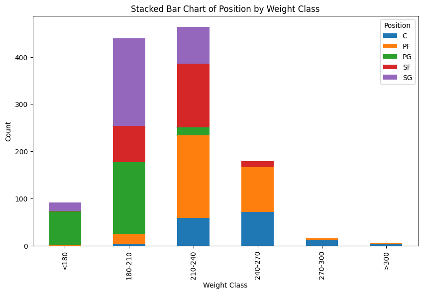

```python
data = pd.crosstab(weight_df['weight_class'], weight_df['position'])

data.plot(kind='bar', stacked=True, figsize=(10, 6))
plt.title('Stacked Bar Chart of Position by Weight Class')
plt.xlabel('Weight Class')
plt.ylabel('Count')
plt.legend(title='Position')
plt.show()
```

# 5 - Primary Analysis

**Goal**: We are trying to predict the position of a player based on a variety of factors including height, weight, bench amount, and body fat percentage. We will construct a model that takes these factors into consideration

```python
strength_df = df[['position', 'height_without_shoes', 'weight', 'body_fat_pct', 'bench_press', 'wingspan', 'lane_agility_time', 'standing_reach', 'hand_length']]
strength_df = strength_df.dropna()
strength_df.drop('Unknown', inplace=True, errors='ignore')
strength_df['position'] = strength_df['position'].apply(lambda x: 'PG' if x in ['PG', 'PG-SG'] else x)
strength_df['position'] = strength_df['position'].apply(lambda x: 'SG' if x in ['SG', 'SG-PG', 'SG-SF'] else x)
strength_df['position'] = strength_df['position'].apply(lambda x: 'SF' if x in ['SF', 'SF-SG', 'SF-PF'] else x)
strength_df['position'] = strength_df['position'].apply(lambda x: 'PF' if x in ['PF', 'PF-SF','PF-C'] else x)
strength_df['position'] = strength_df['position'].apply(lambda x: 'C' if x in ['C', 'C-PF'] else x)

features = strength_df[['height_without_shoes', 'weight', 'body_fat_pct', 'bench_press', 'wingspan', 'lane_agility_time', 'standing_reach']]
target = strength_df['position']

label_encoder = LabelEncoder()
target_encoded = label_encoder.fit_transform(target)


X_train, X_test, y_train, y_test = train_test_split(features, target_encoded, test_size=0.3, random_state=42)

# Scale the features
scaler = StandardScaler()
X_train_scaled = scaler.fit_transform(X_train)
X_test_scaled = scaler.transform(X_test)


models = {
    'KNN': KNeighborsClassifier(),
    'DecisionTree': DecisionTreeClassifier(random_state=42),
    'LogisticRegression': LogisticRegression(max_iter=1000, random_state=42),
    'RandomForest': RandomForestClassifier(random_state=42)
}

# Train and evaluate each model
for model_name, model in models.items():
    print(f"Training {model_name}...")
    model.fit(X_train_scaled, y_train)
    y_pred = model.predict(X_test_scaled)
    print(f"Accuracy for {model_name}: {accuracy_score(y_test, y_pred)}")
    print(f"Classification Report for {model_name}:\n{classification_report(y_test, y_pred, target_names=label_encoder.classes_)}\n")
```

```
Training KNN...
Accuracy for KNN: 0.6565096952908587
Classification Report for KNN:
              precision    recall  f1-score   support

           C       0.70      0.62      0.66        50
          PF       0.61      0.71      0.66        89
          PG       0.79      0.76      0.78        76
          SF       0.55      0.48      0.52        64
          SG       0.64      0.67      0.65        81
     Unknown       0.00      0.00      0.00         1

    accuracy                           0.66       361
   macro avg       0.55      0.54      0.54       361
weighted avg       0.66      0.66      0.65       361


Training DecisionTree...
Accuracy for DecisionTree: 0.6066481994459834
Classification Report for DecisionTree:
              precision    recall  f1-score   support

           C       0.62      0.66      0.64        50
          PF       0.60      0.55      0.58        89
          PG       0.75      0.71      0.73        76
          SF       0.47      0.59      0.52        64
          SG       0.62      0.56      0.58        81
     Unknown       0.00      0.00      0.00         1

    accuracy                           0.61       361
   macro avg       0.51      0.51      0.51       361
weighted avg       0.61      0.61      0.61       361


Training LogisticRegression...
Accuracy for LogisticRegression: 0.7285318559556787
Classification Report for LogisticRegression:
              precision    recall  f1-score   support

           C       0.84      0.62      0.71        50
          PF       0.73      0.82      0.77        89
          PG       0.87      0.76      0.81        76
          SF       0.60      0.64      0.62        64
          SG       0.67      0.74      0.71        81
     Unknown       0.00      0.00      0.00         1

    accuracy                           0.73       361
   macro avg       0.62      0.60      0.60       361
weighted avg       0.74      0.73      0.73       361


Training RandomForest...
```

```
Accuracy for RandomForest: 0.6925207756232687
Classification Report for RandomForest:
              precision    recall  f1-score   support

           C       0.82      0.64      0.72        50
          PF       0.64      0.73      0.68        89
          PG       0.85      0.75      0.80        76
          SF       0.58      0.61      0.60        64
          SG       0.66      0.70      0.68        81
     Unknown       0.00      0.00      0.00         1

    accuracy                           0.69       361
   macro avg       0.59      0.57      0.58       361
weighted avg       0.70      0.69      0.69       361
```

The ML technique we will be using is Logistic Regression because that yielded the highest accuracy, precision and recall on the testing set.

# 6 - Visualization

**Feature Correlation Visualization**

The goal of a feature correlation visualization is to show which factors have a strong relationship and which ones have no relationship. It also helps us understand if we have multicolinearity so that we don't double count variables. Additionally if two variables have no relationship then it is possible that one could be removed to reduce noise.

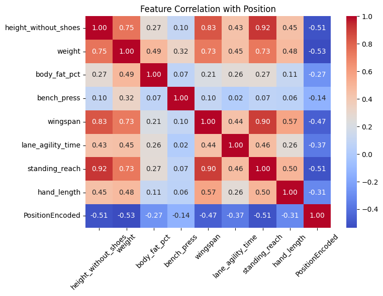

```python
df = strength_df[strength_df['position'] != 'Unknown']
label_encoder = LabelEncoder()
df['PositionEncoded'] = label_encoder.fit_transform(df['position'])

numeric_df = df.select_dtypes(include=['number'])

correlation_matrix = numeric_df.corr()


plt.figure(figsize=(8, 6))
sns.heatmap(correlation_matrix, annot=True, cmap="coolwarm", fmt=".2f", cbar=True)
plt.title("Feature Correlation with Position")
plt.xticks(rotation=45)
plt.yticks(rotation=0)
plt.tight_layout()
plt.show()
```

Analysis: Looking at the bottom row of the heatmap, we can see how each feature correlates with player position. The strongest connections are with weight, height without shoes, and standing reach, which have negative correlations. This means taller, heavier players with longer reach tend to fit certain positions better. Wingspan and lane agility time also play a role but aren’t as strongly linked. On the other hand, things like bench press and body fat percentage don’t seem to matter much for position. Overall, a player’s size and reach are the biggest factors.

# **Linear Regression Visualization**

Linear Regressional Visualization shows the relationship between each of the features and position. This provides us with another way of seeing the correlations we saw in the feature correlation visualization. The steeper lines show that there is a stronger relationship between the feature and position.

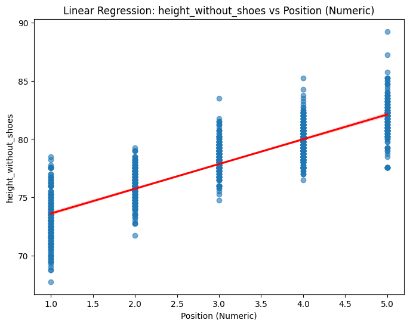

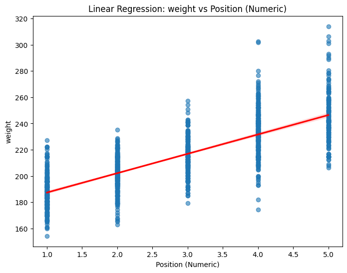

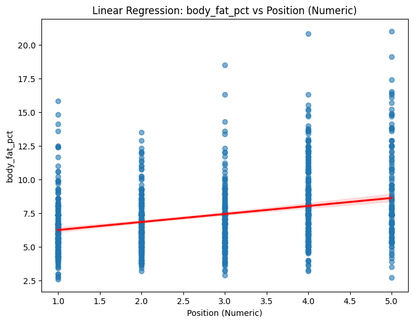

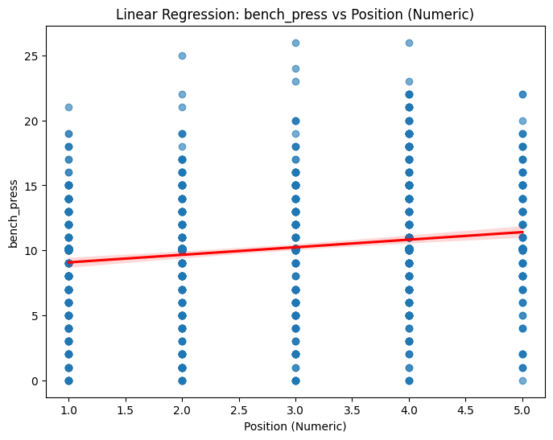

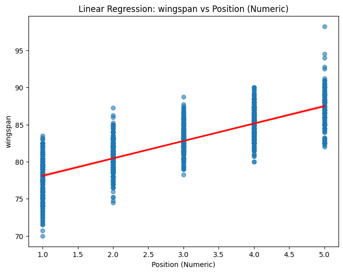

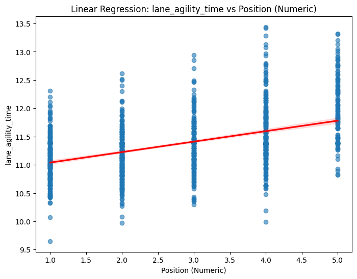

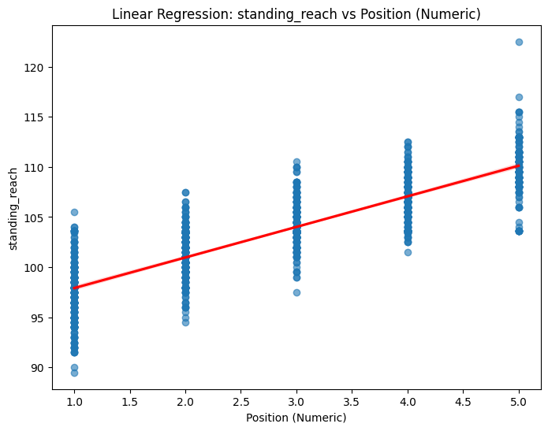

```python
position_mapping = {"PG": 1, "SG": 2, "SF": 3, "PF": 4, "C": 5}
strength_df["position_numeric"] = strength_df["position"].map(position_mapping)


features = strength_df[['height_without_shoes', 'weight', 'body_fat_pct', 'bench_press', 'wingspan', 'lane_agility_time', 'standing_reach']]



for feature in features:
    plt.figure(figsize=(8, 6))
    sns.regplot(
        x="position_numeric",
        y=feature,
        data=strength_df,
        scatter_kws={'alpha': 0.6},
        line_kws={'color': 'red'}
    )
    plt.title(f"Linear Regression: {feature} vs Position (Numeric)")
    plt.xlabel("Position (Numeric)")
    plt.ylabel(feature)
    plt.show()
```

Analysis: Based on the linear regression visualizations, we can observe the relationships between various physical attributes and the position of players. The linear regression analysis confirms some of the trends identified in the correlations. Taller players with larger standing reach and wingspan tend to play in positions like power forward (PF) or center (C), as indicated by the positive slopes. These attributes have a stronger correlation with position than features like body fat percentage or bench press. The relationships indicate that size-related features (height, wingspan, standing reach) are important differentiators across player positions, while other physical features like agility and strength show weaker associations with position.

# 7 - Insights and Conclusions

**Insight and Policy Decisions**

Future Directions: Expanding the dataset to include gameplay statistics and historical trends could provide deeper insights, enhancing recruitment and training strategies further. Additionally, integrating real-time player performance metrics could refine the predictive accuracy of our models. Overall, the results demonstrate that physical attributes are strong predictors of player positions, validating the importance of tailored analysis in sports data science. Future research could explore position-specific injury risks or optimize player fitness programs using advanced predictive analytics.